# BST260WHR project

Sung-An Tai, Ellen Kao, Flora Chang, Allina Chang

2020/12/9

[Data link](https://docs.google.com/spreadsheets/d/1vkHkvnZFhtekjkYbF-y7uVo4oE36ROaqJx4lxVIkdq4/edit?usp=sharing) for Figure 2.1 of 2020 WHR Report

[Data link](https://docs.google.com/spreadsheets/d/1bAzkkXU3W7LALAzP2cnaahbf-s52kr8GvjJ3pIaK9Cs/edit?usp=sharing) for Table 2.1 of 2020 WHR Report

```r
library(tidyverse)
library(readxl)
library(gsheet)
library(MASS)
library(ggplot2)
library(grid)
library(gridExtra)
library(asbio)
library(rvest)
library(maps)
library(randomForest)
library(caret)
library(sf)
library(ggrepel)
library(ggspatial)
library(gsheet)
```

# Overview and Motivation

In our own ways, we are all seeking happiness, not only for us, but also for our loved ones. We wanted to choose a topic that is relatable for everyone. Thus, we looked into the World Happiness Report. The World Happiness Report is a landmark survey of the state of global happiness that ranks countries by how happy their citizens perceive themselves to be. Especially during this new COVID-19 reality that we are living in, external factors can often shake our happiness. We thought it would be interesting to dig deeper into the predictors of happiness. With team members located in Taiwan and the US, we also wanted to choose a topic that compares and contrasts across countries. Through this project, we hoped to gain insight about how happiness trends vary across different countries, how different variables may or may not explain happiness, and how happiness can be predicted in the future.

# Related Work

The world map on the midterm inspired us to visualize data across the entire world, and current day events revolving COVID-19 led us to choose a topic that is largely impacted by the consequences of the pandemic.

# Initial Questions

Our initial question was: How does happiness vary across the world? After beginning to look into the data and starting to visualize the results, additional questions arose such as: Does geographical location play a role in happiness levels? Are countries that are closer to the equator happier? Which variables predict happiness? How does happiness change as a function of time? Are first-world countries happier than second- or third-world countries?

# Data Visualization

First, we read in the data pulled from the 2020 World Happiness Report. We decided to use the datasets for Table 2.1 and Figure 2.1 in the report.

```r
#Figure 2.1
url20 <- "https://docs.google.com/spreadsheets/d/1vkHkvnZFhtekjkYbF-y7uVo4oE36ROaqJx4lxVIkdq4/edit?usp=sharing"
dat20 <- gsheet2tbl(url20, sheetid = NULL)

#Table 2.1
dat2_1 <- "https://docs.google.com/spreadsheets/d/1bAzkkXU3W7LALAzP2cnaahbf-s52kr8GvjJ3pIaK9Cs/edit?usp=sharing"
whr2_1 <- gsheet2tbl(dat2_1, sheetid = NULL)
```

We chose to visualize happiness levels across the world in 2019 and make some conclusions about whether or not happiness is regionally correlated. We also thought it would be interesting to visualize how discrepant happiness levels could be within continents.

We also visualized happiness across the years as well as the relation of the Ladder Score to other variables in a [Shiny app](https://changallina.shinyapps.io/bst260finalproject/) format. Our Shiny app has two tabs, the first visualizes happiness trends over the years and the second visualizes how happiness correlates with other country characteristics.

1. Happiness trends: The user is allowed to select up to six countries at once. Although not every country has Country Ladder score data for every year, we chose to make the x-axis flexible to input and display the entire range of years (2005 to 2019) when appropriate. An interesting conclusion is that the United States has actually been on a slight downward trend in terms of overall “happiness.” Some [reports](https://www.washingtonpost.com/nation/2019/03/21/americans-are-unhappiest-theyve-ever-been-un-report-finds-an-epidemic-addictions-could-be-blame/) attribute this decline to an “epidemic of addiction,” which covers everything from substance abuse to social media. In turn, these addictions are causing higher rates of depression and general unhappiness among the population. Our Shiny app makes it easy to visualize, compare, and contrast happiness in different countries and across multiple years. These trends can be used as starting points of future research.
2. Dynamics of variables: In the second tab, the user is allowed to select up to three countries at once as well as any continuous range of years between 2005 and 2019. This tab aimed to visualize the relationship between happiness and other variables, including GDP, healthy life expectancy at birth, social support, freedom to make life choices, generosity, and perceptions of corruption. The y-axis represents the value of the Cantril Ladder score while the x-axis represents the value of the selected variable. Based on this plot, users can visualize the correlation between a specified variable and happiness while also viewing how these trends may differ across countries. This visualization provides insight into the strength and role with which a variable may play in relation to overall happiness. For example, when “Italy”, “Taiwan”, and the “United States” are selected along with GDP, it’s apparent that GDP is quite positively correlated with happiness scores. This is consistent with [research](https://psycnet.apa.org/record/2009-09430-011) indicating that judgment measures, such as the Cantril Ladder score, are strongly associated with income as well as long-term changes of national income. The higher GDP per capita, the higher the Ladder score. Of course, we know that GDP is not the only predictor of happiness (or even close to!), so we still need to consider other possible predictors of happiness.

Our next visualization involved creating and filling in a world map according to 2019 Ladder scores. In this first code chunk, we combined our dataframe containing data from Figure 2.1 of the 2020 World Happiness Report with a world map dataframe. In order to do so, we had to rename some of the countries so that they would match up between the two sets of data. Additionally, we wanted to include Hong Kong as its own country/region instead of treating it as a subregion within China, as the world map dataset did.

To make our final world map easier to interpret, we incremented Cantril Ladder Scores by 0.5. Since there were no ladder scores below 2, that was the lower bound of our first category.

```r
world_map = map_data("world")

dat20 <- dat20 %>%
  mutate(new_names = recode(`Country name`,
    "United Kingdom" = "UK",
    "United States" = "USA",
    "Taiwan Province of China" = "Taiwan",
    "Trinidad and Tobago" = "Trinidad",
    "North Cyprus" = "Cyprus",
    "Hong Kong S.A.R. of China" = "Hong Kong",
    "Palestinian Territories" = "Palestine",
    "Congo (Brazzaville)" = "Democratic Republic of the Congo"
  )
  )

world_map <- within(world_map, region[region == "China" & subregion == "Hong Kong"] <- "Hong Kong")

world_map <- world_map %>%
  filter(region != "Antarctica") %>%
  rename("Country" = region)

dat20 <- dat20 %>%
  rename("Country" = new_names)

combined_countries <- full_join(dat20, world_map)
combined_countries <- combined_countries %>% mutate(manual_fill = cut(`Ladder score`,
                         breaks = c(2, 2.5, 3, 3.5, 4, 4.5, 5, 5.5, 6, 6.5, 7, 7.5, 8, Inf),
                         labels = c("(2, 2.5]", "(2.5, 3]", "(3, 3.5]", "(3.5, 4]", "(4, 4.5]",
                                    "(4.5, 5]", "(5, 5.5]", "(5.5, 6]", "(6, 6.5]",
                                    "(6.5, 7]", "(7, 7.5]", "(7.5, 8]", ">8"),
                         right = TRUE))

whr2_1 <- whr2_1 %>% rename(GDP = `Log GDP per capita`,
                            "LifeExpectancy" = `Healthy life expectancy at birth`,
                            "SocialSupport" = `Social support`,
                            "PerceptionsOfCorruption" = `Perceptions of corruption`)
```

In this section of code, we identified the lowest and highest Cantril ladder scores within each continent. As Australia can be considered as its own continent, we did not indicate the lowest-ladder score in that region.

```r
topcities <- data.frame(Country = c("Taiwan", "Australia", "Mauritius", "Chile", "Canada", "Finland"),
    lat = c(23.6978, -43.23242, -20.48486, -33.447487, 56.1394, 60.04068),
    lng = c(120.9605, 147.3488, 57.65127, -70.673676, -106.3468, 20.61133),
    level = c("happiest", "happiest", "happiest", "happiest", "happiest", "happiest"))

(topcities <- st_as_sf(topcities, coords = c("lng", "lat"), remove = FALSE,
    crs = 4326, agr = "constant"))
```

```
## Simple feature collection with 6 features and 4 fields
## Attribute-geometry relationship: 4 constant, 0 aggregate, 0 identity
## geometry type:  POINT
## dimension:      XY
## bbox:           xmin: -106.3468 ymin: -43.23242 xmax: 147.3488 ymax: 60.04068
## geographic CRS: WGS 84
##     Country       lat        lng    level                    geometry
## 1    Taiwan  23.69780  120.96050 happiest    POINT (120.9605 23.6978)
## 2 Australia -43.23242  147.34880 happiest  POINT (147.3488 -43.23242)
## 3 Mauritius -20.48486   57.65127 happiest  POINT (57.65127 -20.48486)
## 4     Chile -33.44749  -70.67368 happiest POINT (-70.67368 -33.44749)
## 5    Canada  56.13940 -106.34680 happiest   POINT (-106.3468 56.1394)
## 6   Finland  60.04068   20.61133 happiest   POINT (20.61133 60.04068)
```

```r
lowcities <- data.frame(Country = c("Venezuela", "Haiti", "South Sudan", "Ukraine", "Afghanistan"),
    lat = c(6.4238, 18.9715, 6.8770, 48.3794, 33.9391),
    lng = c(-66.5897, -72.2852, 31.3070, 31.1656, 67.6100),
    level = c("saddest", "saddest", "saddest", "saddest", "saddest"))

(lowcities <- st_as_sf(lowcities, coords = c("lng", "lat"), remove = FALSE,
    crs = 4326, agr = "constant"))
```

```
## Simple feature collection with 5 features and 4 fields
## Attribute-geometry relationship: 4 constant, 0 aggregate, 0 identity
## geometry type:  POINT
## dimension:      XY
## bbox:           xmin: -72.2852 ymin: 6.4238 xmax: 67.61 ymax: 48.3794
## geographic CRS: WGS 84
##       Country     lat      lng   level                 geometry
## 1   Venezuela  6.4238 -66.5897 saddest  POINT (-66.5897 6.4238)
## 2       Haiti 18.9715 -72.2852 saddest POINT (-72.2852 18.9715)
## 3 South Sudan  6.8770  31.3070 saddest     POINT (31.307 6.877)
## 4     Ukraine 48.3794  31.1656 saddest  POINT (31.1656 48.3794)
## 5 Afghanistan 33.9391  67.6100 saddest    POINT (67.61 33.9391)
```

```r
mostleast <- rbind(topcities, lowcities)
```

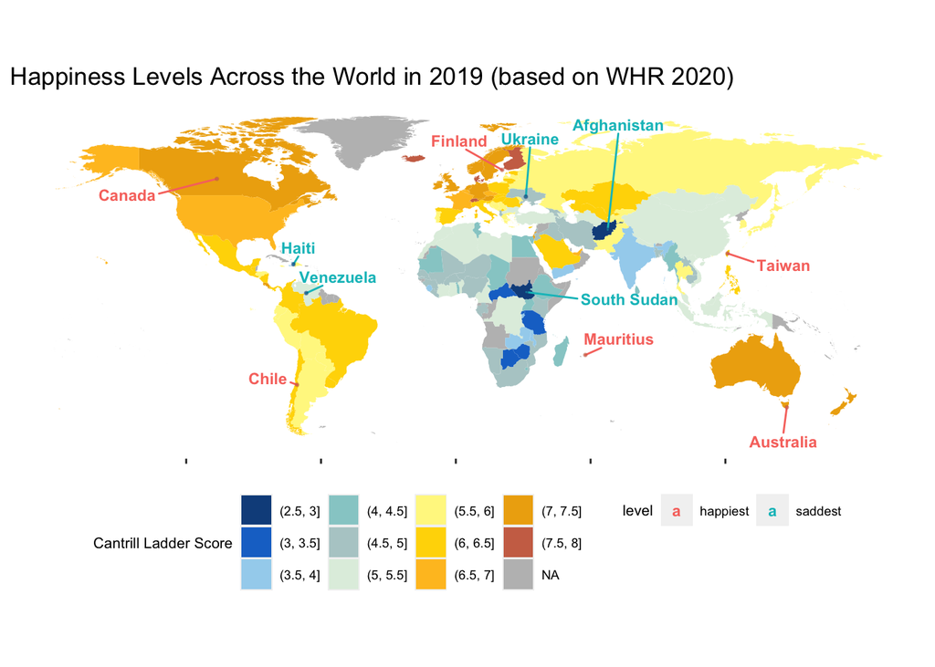

```r
ggplot() +
  geom_polygon(combined_countries, mapping = aes(x = long, y = lat, group = group, fill = manual_fill)) +
  geom_text_repel(data = mostleast, aes(x = lng, y = lat, label = Country, color = level),
                  size = 3,
                  fontface = "bold",
                  nudge_x = c(25, -1.5, 15, -13, -40, -16, 8, 3, 46, 3, 2),
                  nudge_y = c(-5, -15, 7, 3, -7, 13, 10, 7, -3, 26, 45),
                  min.segment.length = unit(0, "lines")) +
  geom_sf(data = topcities, alpha = 0.5, size = 0.5, color = "salmon3") +
  geom_sf(data = lowcities, alpha = 0.5, size = 0.5, color = "dodgerblue4") +
  ggtitle("Happiness Levels Across the World in 2019 (based on WHR 2020)") +
  scale_fill_manual(name = "Cantrill Ladder Score",
                     values = c("dodgerblue4",
                                "dodgerblue3",
                                "lightskyblue2",
                                "paleturquoise3",
                                "lightcyan3",
                                "honeydew2",
                                "khaki1",
                                "gold1",
                                "goldenrod1",
                                "darkgoldenrod2",
                                "salmon3"),
                    na.value = "gray") +
  theme(legend.position = "bottom",
        legend.title = element_text(size = 8),
        legend.text = element_text(size = 7)) +
  guides(shape = guide_legend(override.aes = list(size = 5))) +
  theme(panel.grid.major = element_blank(),
        panel.background = element_blank(),
        axis.title = element_blank(),
        axis.text = element_blank(),
        axis.ticks.y = element_blank(),
        axis.line.y = element_blank())
```

# Data Analysis: Regression

```r
# Read WHR20_DataForFigure2.1.xls (2017~2019 average) and WHR20_DataForTable2.1.xls (2008~2019 with additional variables)
# Main dependent variable: Ladder score, independent variable: `Logged GDP per capita`+`Social support`+`Healthy life expectancy`+`Freedom to make life choices`+`Generosity`+`Perceptions of corruption`
whr20 <- gsheet2tbl("https://docs.google.com/spreadsheets/d/1jVOpMfl94xDmip0NrJEXORoFK4RBfB7leDVzyJnk47w/edit#gid=28299357", sheetid = NULL)
whr_all <- gsheet2tbl("https://docs.google.com/spreadsheets/d/1oMzplKOmjs0hKKmXKqOCM90CvPsS7aCIj1adox0nvNU/edit#gid=1261774380", sheetid = NULL)
```

We first look at the regression model for the pooled data of 2017-2019

```r
# Main model for fig 2.1 in the WHR 2020 report, but they used pooled OLS regression specific for panel analysis, rather than plain multiple regression
mod1 <- lm(`Ladder score` ~ `Logged GDP per capita`+
             `Social support`+`Healthy life expectancy`+
             `Freedom to make life choices`+
             `Generosity`+
             `Perceptions of corruption`,
           data = whr20)
summary(mod1)
```

```
##
## Call:
## lm(formula = `Ladder score` ~ `Logged GDP per capita` + `Social support` +
##     `Healthy life expectancy` + `Freedom to make life choices` +
##     Generosity + `Perceptions of corruption`, data = whr20)
##
## Residuals:
##      Min       1Q   Median       3Q      Max
## -1.75647 -0.31792  0.06653  0.37230  1.48375
##
## Coefficients:
##                                Estimate Std. Error t value Pr(>|t|)
## (Intercept)                    -2.05938    0.63984  -3.219 0.001588 **
## `Logged GDP per capita`         0.22908    0.08208   2.791 0.005960 **
## `Social support`                2.72332    0.66118   4.119 6.35e-05 ***
## `Healthy life expectancy`       0.03531    0.01297   2.721 0.007293 **
## `Freedom to make life choices`  1.77682    0.49752   3.571 0.000481 ***
## Generosity                      0.41057    0.33704   1.218 0.225126
## `Perceptions of corruption`    -0.62816    0.31480  -1.995 0.047857 *
## ---
## Signif. codes:  0 '***' 0.001 '**' 0.01 '*' 0.05 '.' 0.1 ' ' 1
##
## Residual standard error: 0.5693 on 146 degrees of freedom
## Multiple R-squared:  0.7483, Adjusted R-squared:  0.738
## F-statistic: 72.36 on 6 and 146 DF,  p-value: < 2.2e-16
```

Then, we tried to see how much variance each variable explained in the data by looking at partial R2.

```r
#Logged GDP per capita explained about 5% of the variance in the model.
lm.with<-lm(`Ladder score` ~ `Logged GDP per capita`+
             `Social support`+`Healthy life expectancy`+
             `Freedom to make life choices`+
             `Generosity`+
             `Perceptions of corruption`,
           data = whr20)

lm.without<-update(lm.with, ~. - `Logged GDP per capita`)

R2_gdp <-  partial.R2(lm.without,lm.with)
R2_gdp
```

```
## [1] 0.05064557
```

```r
## Social support explained 10% of the variance in the model.

lm.with<-lm(`Ladder score` ~ `Logged GDP per capita`+
             `Social support`+`Healthy life expectancy`+
             `Freedom to make life choices`+
             `Generosity`+
             `Perceptions of corruption`,
           data = whr20)

lm.without.2<-update(lm.with, ~. - `Social support`)

R2_social_support <-  partial.R2(lm.without.2,lm.with)
R2_social_support
```

```
## [1] 0.1041042
```

```r
##Healthy life expectancy explained 4.8% of the variance in the model.
lm.with<-lm(`Ladder score` ~ `Logged GDP per capita`+
             `Social support`+`Healthy life expectancy`+
             `Freedom to make life choices`+
             `Generosity`+
             `Perceptions of corruption`,
           data = whr20)

lm.without.3<-update(lm.with, ~. - `Healthy life expectancy`)

R2_healthy_life_expectancy <-  partial.R2(lm.without.3,lm.with)
R2_healthy_life_expectancy
```

```
## [1] 0.04827558
```

```r
## Freedom to make life choices explained 8% of the variance in the model.
lm.with<-lm(`Ladder score` ~ `Logged GDP per capita`+
             `Social support`+`Healthy life expectancy`+
             `Freedom to make life choices`+
             `Generosity`+
             `Perceptions of corruption`,
           data = whr20)

lm.without.4<-update(lm.with, ~. - `Freedom to make life choices`)

R2_choice <-  partial.R2(lm.without.4,lm.with)
R2_choice
```

```
## [1] 0.08034042
```

```r
##Generostiy explained 1% of the variance in the model.
lm.with<-lm(`Ladder score` ~ `Logged GDP per capita`+
             `Social support`+`Healthy life expectancy`+
             `Freedom to make life choices`+
             `Generosity`+
             `Perceptions of corruption`,
           data = whr20)

lm.without.5<-update(lm.with, ~. - `Generosity`)

R2_generosity <-  partial.R2(lm.without.5,lm.with)
R2_generosity
```

```
## [1] 0.01006163
```

```r
## Perceptions of corruption explained 2.7% of the variance in the model.
lm.with<-lm(`Ladder score` ~ `Logged GDP per capita`+
             `Social support`+`Healthy life expectancy`+
             `Freedom to make life choices`+
             `Generosity`+
             `Perceptions of corruption`,
           data = whr20)

lm.without.6<-update(lm.with, ~. - `Perceptions of corruption`)

R2_corruption <-  partial.R2(lm.without.6,lm.with)
R2_corruption
```

```
## [1] 0.02654808
```

Based on the partial R squared results, we found the the top 3 variables which explained the most variance in the model were “Social support” (10%), “Freedom to make life choices” (8%), and “Logged GDP per capita” (5%).

After we ran multiple regression on the data (2017-2019), we found that five out of six variables were significant. The only exception was generosity. Therefore, we have ran some scatter plots to see the relationship between happiness score (ladder score) and each variable. From the scatter plots below, we found that it seems that there was not a linear relationship between generosity and happiness score and between perceptions of corruption and happiness score.

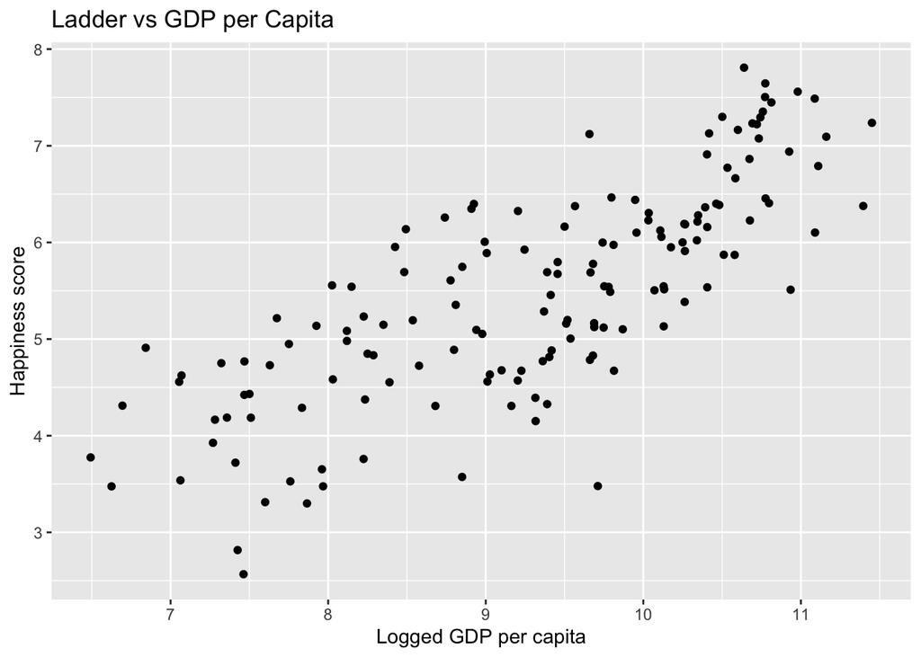

```r
p_1 <- whr20 %>%
  ggplot(aes(x= `Logged GDP per capita`, y= `Ladder score`)) +
    geom_point() +
    ylab("Happiness score")  +
    xlab("Logged GDP per capita") +
  ggtitle("Ladder vs GDP per Capita")

p_1
```

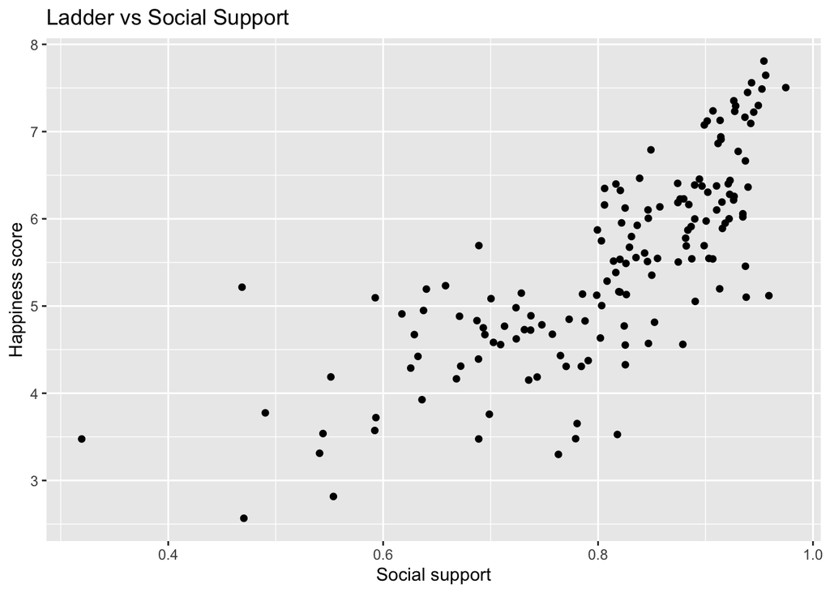

```r
p_2 <- whr20 %>%
  ggplot(aes(x= `Social support`, y= `Ladder score`)) +
    geom_point() +
    ylab("Happiness score")  +
    xlab("Social support") +
  ggtitle("Ladder vs Social Support")

p_2
```

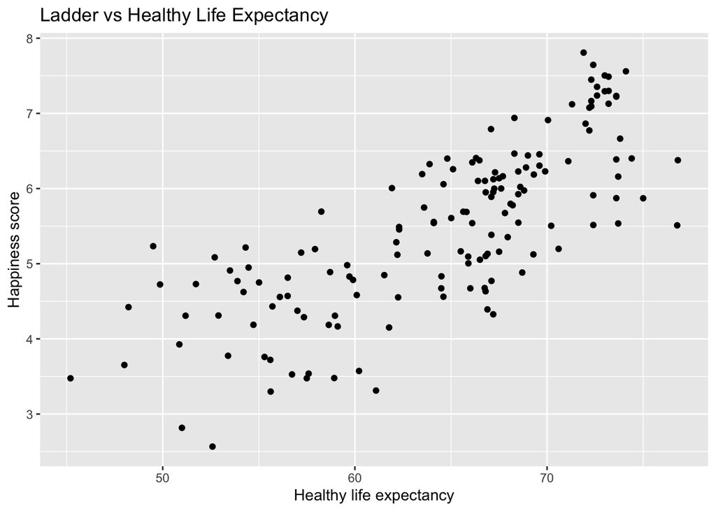

```r
p_3 <- whr20 %>%
  ggplot(aes(x= `Healthy life expectancy`, y= `Ladder score`)) +
    geom_point() +
    ylab("Happiness score")  +
    xlab("Healthy life expectancy") +
  ggtitle("Ladder vs Healthy Life Expectancy")

p_3
```

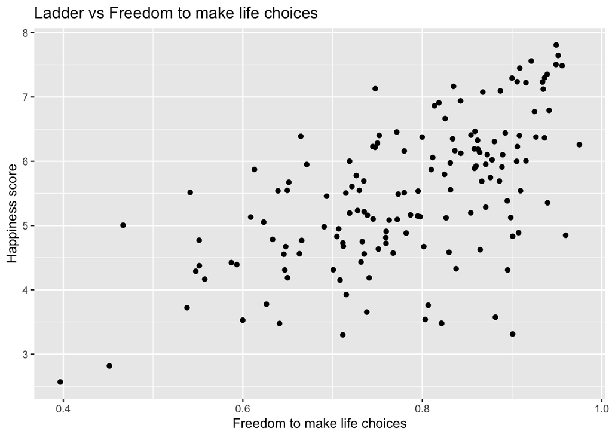

```r
p_4 <- whr20 %>%
  ggplot(aes(x= `Freedom to make life choices`, y= `Ladder score`)) +
    geom_point() +
    ylab("Happiness score")  +
    xlab("Freedom to make life choices") +
  ggtitle("Ladder vs Freedom to make life choices")

p_4
```

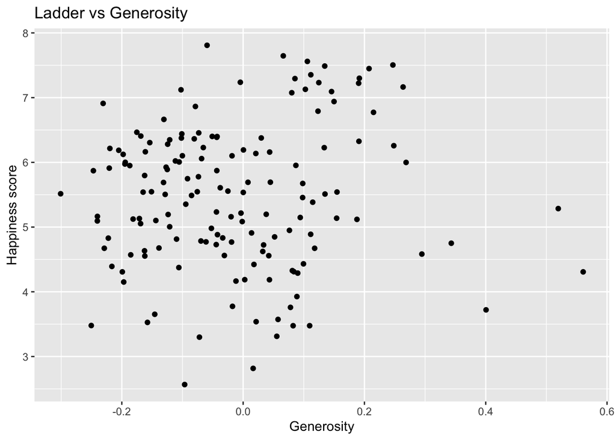

```r
p_5 <- whr20 %>%
    ggplot(aes(x= `Generosity`, y= `Ladder score`)) +
    geom_point() +
    ylab("Happiness score")  +
    xlab("Generosity") +
  ggtitle("Ladder vs Generosity")

p_5
```

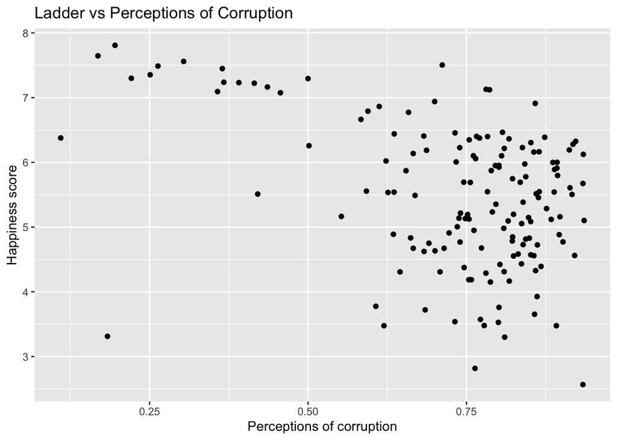

```r
p_6 <- whr20 %>%
  ggplot(aes(x= `Perceptions of corruption`, y= `Ladder score`)) +
    geom_point() +
    ylab("Happiness score")  +
    xlab("Perceptions of corruption") +
  ggtitle("Ladder vs Perceptions of Corruption")

p_6
```

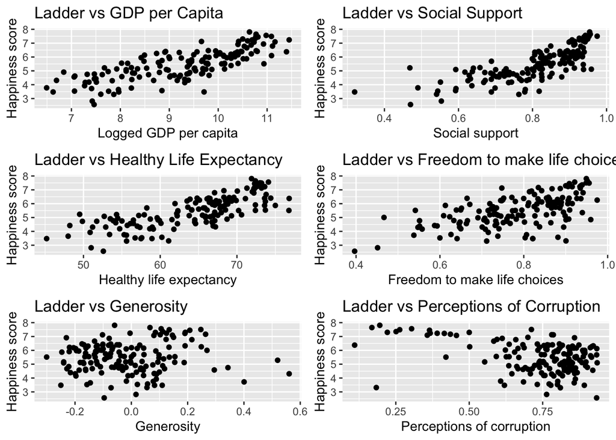

```r
grid.arrange(p_1, p_2, p_3, p_4, p_5, p_6, nrow = 3)
```

Then, we ran some diagnostic plots to check the assumptions for linear regression model(2017-2019 data). Diagnostics seems to fulfill “linearity”,“normality”, and “equal variance” assumptions.

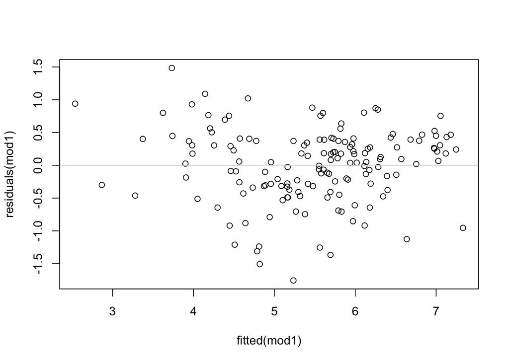

```r
# Residuals versus fitted plot
plot(fitted(mod1), residuals(mod1))
abline(a=0,b=0,col="pink")
```

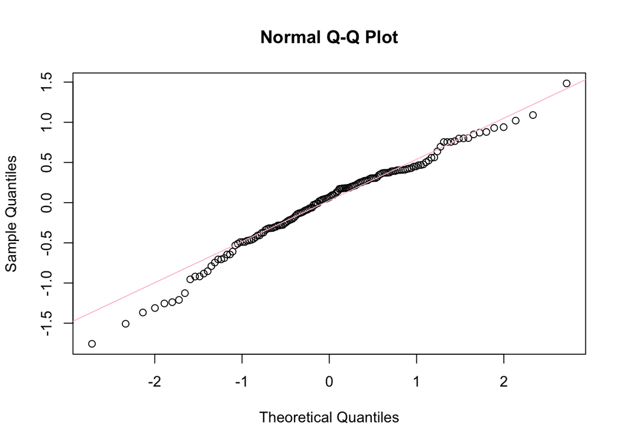

```r
# QQ Norm plot
qqnorm(residuals(mod1))
qqline(residuals(mod1),col="pink")
```

## Multiple regression analyses for 2015 - 2019, separately

```r
# Model from 2015 to 2019
modeling <- function(y){
  whr_df <- whr_all %>% filter(year == y) %>% dplyr::select(`Life Ladder`, `Log GDP per capita`,
             `Social support`, `Healthy life expectancy at birth`,
             `Freedom to make life choices`,
             `Generosity`,
             `Perceptions of corruption`) %>% drop_na()

  mod <- lm(`Life Ladder` ~ `Log GDP per capita`+
             `Social support`+`Healthy life expectancy at birth`+
             `Freedom to make life choices`+
             `Generosity`+
             `Perceptions of corruption`,
           data = whr_df)
  mod
}
years <- 2015:2019
mods.15to19 <- lapply(years, modeling)
names(mods.15to19) <- paste0("mod.", 2015:2019)
lapply(mods.15to19, summary)
```

```
## $mod.2015
##
## Call:
## lm(formula = `Life Ladder` ~ `Log GDP per capita` + `Social support` +
##     `Healthy life expectancy at birth` + `Freedom to make life choices` +
##     Generosity + `Perceptions of corruption`, data = whr_df)
##
## Residuals:
##      Min       1Q   Median       3Q      Max
## -1.58200 -0.35201  0.06346  0.37530  1.48452
##
## Coefficients:
##                                    Estimate Std. Error t value Pr(>|t|)
## (Intercept)                        -2.39717    0.63504  -3.775 0.000250 ***
## `Log GDP per capita`                0.33948    0.09232   3.677 0.000353 ***
## `Social support`                    2.35169    0.54711   4.298  3.5e-05 ***
## `Healthy life expectancy at birth`  0.03553    0.01379   2.577 0.011179 *
## `Freedom to make life choices`      1.23303    0.44472   2.773 0.006441 **
## Generosity                          0.28831    0.32912   0.876 0.382763
## `Perceptions of corruption`        -0.57732    0.31008  -1.862 0.065050 .
## ---
## Signif. codes:  0 '***' 0.001 '**' 0.01 '*' 0.05 '.' 0.1 ' ' 1
##
## Residual standard error: 0.5483 on 121 degrees of freedom
## Multiple R-squared:  0.7865, Adjusted R-squared:  0.7759
## F-statistic:  74.3 on 6 and 121 DF,  p-value: < 2.2e-16
##
##
## $mod.2016
##
## Call:
## lm(formula = `Life Ladder` ~ `Log GDP per capita` + `Social support` +
##     `Healthy life expectancy at birth` + `Freedom to make life choices` +
##     Generosity + `Perceptions of corruption`, data = whr_df)
##
## Residuals:
##      Min       1Q   Median       3Q      Max
## -1.64319 -0.34025 -0.00195  0.38886  1.26875
##
## Coefficients:
```

[output cut: 83 more lines]

```
## Coefficients:
##                                    Estimate Std. Error t value Pr(>|t|)
## (Intercept)                        -1.84299    0.78191  -2.357  0.02017 *
## `Log GDP per capita`                0.08210    0.10592   0.775  0.43989
## `Social support`                    3.35693    0.72426   4.635 9.79e-06 ***
## `Healthy life expectancy at birth`  0.05265    0.01570   3.354  0.00109 **
## `Freedom to make life choices`      1.57283    0.56028   2.807  0.00590 **
## Generosity                          0.27913    0.39259   0.711  0.47858
## `Perceptions of corruption`        -1.02867    0.35984  -2.859  0.00508 **
## ---
## Signif. codes:  0 '***' 0.001 '**' 0.01 '*' 0.05 '.' 0.1 ' ' 1
##
## Residual standard error: 0.5948 on 111 degrees of freedom
## Multiple R-squared:  0.7424, Adjusted R-squared:  0.7285
## F-statistic: 53.33 on 6 and 111 DF,  p-value: < 2.2e-16
```

## Model backward selection for 2015 - 2019

```r
# backward selection for 2017~2019 model
mod1_bkwd <- step(mod1, direction = "backward")
```

```
## Start:  AIC=-165.53
## `Ladder score` ~ `Logged GDP per capita` + `Social support` +
##     `Healthy life expectancy` + `Freedom to make life choices` +
##     Generosity + `Perceptions of corruption`
##
##                                  Df Sum of Sq    RSS     AIC
## - Generosity                      1    0.4810 47.806 -165.98
## <none>                                        47.325 -165.53
## - `Perceptions of corruption`     1    1.2907 48.616 -163.41
## - `Healthy life expectancy`       1    2.4005 49.726 -159.96
## - `Logged GDP per capita`         1    2.5247 49.850 -159.58
## - `Freedom to make life choices`  1    4.1343 51.459 -154.72
## - `Social support`                1    5.4992 52.824 -150.71
##
## Step:  AIC=-165.98
## `Ladder score` ~ `Logged GDP per capita` + `Social support` +
##     `Healthy life expectancy` + `Freedom to make life choices` +
##     `Perceptions of corruption`
##
##                                  Df Sum of Sq    RSS     AIC
## <none>                                        47.806 -165.98
## - `Perceptions of corruption`     1    1.8560 49.662 -162.16
## - `Logged GDP per capita`         1    2.2503 50.056 -160.94
## - `Healthy life expectancy`       1    2.3217 50.128 -160.73
## - `Freedom to make life choices`  1    5.1316 52.938 -152.38
## - `Social support`                1    5.5775 53.384 -151.10
```

```r
summary(mod1_bkwd)
```

```
##
## Call:
## lm(formula = `Ladder score` ~ `Logged GDP per capita` + `Social support` +
##     `Healthy life expectancy` + `Freedom to make life choices` +
##     `Perceptions of corruption`, data = whr20)
##
## Residuals:
##      Min       1Q   Median       3Q      Max
## -1.85079 -0.34528  0.06273  0.38041  1.47120
##
## Coefficients:
##                                Estimate Std. Error t value Pr(>|t|)
## (Intercept)                    -1.93892    0.63320  -3.062 0.002614 **
## `Logged GDP per capita`         0.21370    0.08124   2.631 0.009434 **
## `Social support`                2.74190    0.66209   4.141  5.8e-05 ***
## `Healthy life expectancy`       0.03470    0.01299   2.672 0.008394 **
## `Freedom to make life choices`  1.92196    0.48384   3.972 0.000111 ***
## `Perceptions of corruption`    -0.72755    0.30455  -2.389 0.018165 *
## ---
## Signif. codes:  0 '***' 0.001 '**' 0.01 '*' 0.05 '.' 0.1 ' ' 1
##
## Residual standard error: 0.5703 on 147 degrees of freedom
## Multiple R-squared:  0.7458, Adjusted R-squared:  0.7371
## F-statistic: 86.25 on 5 and 147 DF,  p-value: < 2.2e-16
```

```r
# backward selection from 2015 to 2019
backward.select <- function(y){
  whr_df <- whr_all %>% filter(year == y) %>% dplyr::select(`Life Ladder`, `Log GDP per capita`,
             `Social support`, `Healthy life expectancy at birth`,
             `Freedom to make life choices`,
             `Generosity`,
             `Perceptions of corruption`) %>% drop_na()

  mod <- lm(`Life Ladder` ~ `Log GDP per capita`+
             `Social support`+`Healthy life expectancy at birth`+
             `Freedom to make life choices`+
             `Generosity`+
             `Perceptions of corruption`,
           data = whr_df)
  mod.backward <- step(mod, direction = "backward")
  mod.backward
}

summary(b2015 <- backward.select(2015))
```

```
## Start:  AIC=-147.05
## `Life Ladder` ~ `Log GDP per capita` + `Social support` + `Healthy life expectancy at birth` +
##     `Freedom to make life choices` + Generosity + `Perceptions of corruption`
##
##                                      Df Sum of Sq    RSS     AIC
## - Generosity                          1    0.2307 36.605 -148.24
## <none>                                            36.374 -147.05
## - `Perceptions of corruption`         1    1.0421 37.416 -145.43
## - `Healthy life expectancy at birth`  1    1.9957 38.370 -142.21
## - `Freedom to make life choices`      1    2.3110 38.685 -141.16
## - `Log GDP per capita`                1    4.0648 40.439 -135.49
## - `Social support`                    1    5.5541 41.928 -130.86
##
## Step:  AIC=-148.24
## `Life Ladder` ~ `Log GDP per capita` + `Social support` + `Healthy life expectancy at birth` +
##     `Freedom to make life choices` + `Perceptions of corruption`
##
##                                      Df Sum of Sq    RSS     AIC
## <none>                                            36.605 -148.24
## - `Perceptions of corruption`         1    1.5125 38.117 -145.06
## - `Healthy life expectancy at birth`  1    1.9953 38.600 -143.44
## - `Freedom to make life choices`      1    2.7354 39.340 -141.01
## - `Log GDP per capita`                1    3.8776 40.482 -137.35
## - `Social support`                    1    5.9114 42.516 -131.07
```

```
##
## Call:
## lm(formula = `Life Ladder` ~ `Log GDP per capita` + `Social support` +
##     `Healthy life expectancy at birth` + `Freedom to make life choices` +
##     `Perceptions of corruption`, data = whr_df)
##
## Residuals:
##      Min       1Q   Median       3Q      Max
## -1.61720 -0.33700  0.04031  0.36129  1.50043
##
## Coefficients:
##                                    Estimate Std. Error t value Pr(>|t|)
## (Intercept)                        -2.33309    0.63021  -3.702 0.000322 ***
## `Log GDP per capita`                0.32851    0.09138   3.595 0.000469 ***
## `Social support`                    2.40884    0.54269   4.439    2e-05 ***
## `Healthy life expectancy at birth`  0.03553    0.01378   2.579 0.011102 *
## `Freedom to make life choices`      1.31297    0.43484   3.019 0.003085 **
## `Perceptions of corruption`        -0.66139    0.29458  -2.245 0.026557 *
## ---
## Signif. codes:  0 '***' 0.001 '**' 0.01 '*' 0.05 '.' 0.1 ' ' 1
##
## Residual standard error: 0.5478 on 122 degrees of freedom
## Multiple R-squared:  0.7852, Adjusted R-squared:  0.7764
## F-statistic: 89.18 on 5 and 122 DF,  p-value: < 2.2e-16
```

```r
summary(b2016 <- backward.select(2016))
```

```
## Start:  AIC=-139.38
## `Life Ladder` ~ `Log GDP per capita` + `Social support` + `Healthy life expectancy at birth` +
##     `Freedom to make life choices` + Generosity + `Perceptions of corruption`
##
##                                      Df Sum of Sq    RSS     AIC
## - `Perceptions of corruption`         1    0.1268 36.771 -140.95
## <none>                                            36.644 -139.38
## - Generosity                          1    1.1354 37.779 -137.57
## - `Healthy life expectancy at birth`  1    2.5212 39.165 -133.07
## - `Freedom to make life choices`      1    3.1865 39.831 -130.96
## - `Log GDP per capita`                1    4.2268 40.871 -127.74
## - `Social support`                    1    4.9857 41.630 -125.44
##
## Step:  AIC=-140.95
## `Life Ladder` ~ `Log GDP per capita` + `Social support` + `Healthy life expectancy at birth` +
##     `Freedom to make life choices` + Generosity
##
##                                      Df Sum of Sq    RSS     AIC
## <none>                                            36.771 -140.95
## - Generosity                          1    1.4113 38.182 -138.24
## - `Healthy life expectancy at birth`  1    2.5500 39.321 -134.57
## - `Freedom to make life choices`      1    4.2060 40.977 -129.41
## - `Log GDP per capita`                1    4.6509 41.422 -128.06
## - `Social support`                    1    4.8637 41.634 -127.42
```

```
##
## Call:
## lm(formula = `Life Ladder` ~ `Log GDP per capita` + `Social support` +
##     `Healthy life expectancy at birth` + `Freedom to make life choices` +
##     Generosity, data = whr_df)
##
## Residuals:
##      Min       1Q   Median       3Q      Max
## -1.64039 -0.34534  0.01309  0.37831  1.27014
##
## Coefficients:
##                                    Estimate Std. Error t value Pr(>|t|)
## (Intercept)                        -3.51411    0.45581  -7.710 4.23e-12 ***
## `Log GDP per capita`                0.35006    0.09023   3.880 0.000172 ***
## `Social support`                    2.27357    0.57307   3.967 0.000125 ***
## `Healthy life expectancy at birth`  0.04012    0.01397   2.873 0.004820 **
## `Freedom to make life choices`      1.63621    0.44349   3.689 0.000340 ***
## Generosity                          0.71686    0.33543   2.137 0.034633 *
## ---
## Signif. codes:  0 '***' 0.001 '**' 0.01 '*' 0.05 '.' 0.1 ' ' 1
##
## Residual standard error: 0.5559 on 119 degrees of freedom
## Multiple R-squared:  0.7886, Adjusted R-squared:  0.7797
## F-statistic: 88.76 on 5 and 119 DF,  p-value: < 2.2e-16
```

```r
summary(b2017 <- backward.select(2017))
```

```
## Start:  AIC=-134.47
## `Life Ladder` ~ `Log GDP per capita` + `Social support` + `Healthy life expectancy at birth` +
##     `Freedom to make life choices` + Generosity + `Perceptions of corruption`
##
##                                      Df Sum of Sq    RSS     AIC
## - Generosity                          1    0.2298 43.092 -135.77
## <none>                                            42.862 -134.47
## - `Perceptions of corruption`         1    1.0435 43.906 -133.30
## - `Log GDP per capita`                1    1.9263 44.789 -130.67
## - `Healthy life expectancy at birth`  1    2.3257 45.188 -129.50
## - `Freedom to make life choices`      1    2.7742 45.637 -128.20
## - `Social support`                    1    5.7521 48.614 -119.85
##
## Step:  AIC=-135.77
## `Life Ladder` ~ `Log GDP per capita` + `Social support` + `Healthy life expectancy at birth` +
##     `Freedom to make life choices` + `Perceptions of corruption`
##
##                                      Df Sum of Sq    RSS     AIC
## <none>                                            43.092 -135.77
## - `Perceptions of corruption`         1    1.5888 44.681 -132.99
## - `Log GDP per capita`                1    1.7753 44.867 -132.44
## - `Healthy life expectancy at birth`  1    2.3523 45.444 -130.75
## - `Freedom to make life choices`      1    3.1629 46.255 -128.42
## - `Social support`                    1    5.9446 49.037 -120.71
```

```
##
## Call:
## lm(formula = `Life Ladder` ~ `Log GDP per capita` + `Social support` +
##     `Healthy life expectancy at birth` + `Freedom to make life choices` +
##     `Perceptions of corruption`, data = whr_df)
##
## Residuals:
##     Min      1Q  Median      3Q     Max
## -1.7948 -0.3786  0.0270  0.3605  1.2967
##
## Coefficients:
##                                    Estimate Std. Error t value Pr(>|t|)
## (Intercept)                        -1.99271    0.71831  -2.774  0.00638 **
## `Log GDP per capita`                0.22247    0.09765   2.278  0.02439 *
## `Social support`                    2.89334    0.69399   4.169 5.64e-05 ***
## `Healthy life expectancy at birth`  0.03812    0.01454   2.623  0.00980 **
## `Freedom to make life choices`      1.48906    0.48965   3.041  0.00287 **
## `Perceptions of corruption`        -0.71355    0.33106  -2.155  0.03304 *
## ---
## Signif. codes:  0 '***' 0.001 '**' 0.01 '*' 0.05 '.' 0.1 ' ' 1
##
## Residual standard error: 0.5848 on 126 degrees of freedom
## Multiple R-squared:  0.7448, Adjusted R-squared:  0.7347
## F-statistic: 73.56 on 5 and 126 DF,  p-value: < 2.2e-16
```

```r
summary(b2018 <- backward.select(2018))
```

```
## Start:  AIC=-124.46
## `Life Ladder` ~ `Log GDP per capita` + `Social support` + `Healthy life expectancy at birth` +
##     `Freedom to make life choices` + Generosity + `Perceptions of corruption`
##
##                                      Df Sum of Sq    RSS     AIC
## - Generosity                          1   0.29598 42.984 -125.59
## <none>                                            42.688 -124.46
## - `Perceptions of corruption`         1   1.61228 44.300 -121.76
## - `Healthy life expectancy at birth`  1   1.69869 44.387 -121.51
## - `Log GDP per capita`                1   2.71883 45.407 -118.62
## - `Freedom to make life choices`      1   2.91326 45.601 -118.08
## - `Social support`                    1   2.94625 45.634 -117.99
##
## Step:  AIC=-125.59
## `Life Ladder` ~ `Log GDP per capita` + `Social support` + `Healthy life expectancy at birth` +
##     `Freedom to make life choices` + `Perceptions of corruption`
##
##                                      Df Sum of Sq    RSS     AIC
## <none>                                            42.984 -125.59
## - `Healthy life expectancy at birth`  1    1.7212 44.705 -122.60
## - `Perceptions of corruption`         1    2.1205 45.104 -121.47
## - `Log GDP per capita`                1    2.4365 45.420 -120.58
## - `Social support`                    1    3.0255 46.009 -118.95
## - `Freedom to make life choices`      1    3.6030 46.587 -117.36
```

```
##
## Call:
## lm(formula = `Life Ladder` ~ `Log GDP per capita` + `Social support` +
##     `Healthy life expectancy at birth` + `Freedom to make life choices` +
##     `Perceptions of corruption`, data = whr_df)
##
## Residuals:
##      Min       1Q   Median       3Q      Max
## -1.94572 -0.33034  0.05031  0.34501  1.92596
##
## Coefficients:
##                                    Estimate Std. Error t value Pr(>|t|)
## (Intercept)                        -1.79002    0.74657  -2.398  0.01803 *
## `Log GDP per capita`                0.26368    0.10068   2.619  0.00995 **
## `Social support`                    2.36046    0.80883   2.918  0.00420 **
## `Healthy life expectancy at birth`  0.03391    0.01541   2.201  0.02962 *
## `Freedom to make life choices`      1.73585    0.54505   3.185  0.00184 **
## `Perceptions of corruption`        -0.81399    0.33316  -2.443  0.01600 *
## ---
## Signif. codes:  0 '***' 0.001 '**' 0.01 '*' 0.05 '.' 0.1 ' ' 1
##
## Residual standard error: 0.596 on 121 degrees of freedom
## Multiple R-squared:  0.724,  Adjusted R-squared:  0.7126
## F-statistic: 63.49 on 5 and 121 DF,  p-value: < 2.2e-16
```

```r
summary(b2019 <- backward.select(2019))
```

```
## Start:  AIC=-115.83
## `Life Ladder` ~ `Log GDP per capita` + `Social support` + `Healthy life expectancy at birth` +
##     `Freedom to make life choices` + Generosity + `Perceptions of corruption`
##
##                                      Df Sum of Sq    RSS      AIC
## - Generosity                          1    0.1788 39.449 -117.290
## - `Log GDP per capita`                1    0.2126 39.483 -117.189
## <none>                                            39.270 -115.826
## - `Freedom to make life choices`      1    2.7881 42.058 -109.732
## - `Perceptions of corruption`         1    2.8912 42.161 -109.443
## - `Healthy life expectancy at birth`  1    3.9804 43.251 -106.434
## - `Social support`                    1    7.6003 46.870  -96.949
##
## Step:  AIC=-117.29
## `Life Ladder` ~ `Log GDP per capita` + `Social support` + `Healthy life expectancy at birth` +
##     `Freedom to make life choices` + `Perceptions of corruption`
##
##                                      Df Sum of Sq    RSS      AIC
## - `Log GDP per capita`                1    0.1399 39.589 -118.872
## <none>                                            39.449 -117.290
## - `Freedom to make life choices`      1    3.0719 42.521 -110.441
## - `Perceptions of corruption`         1    3.5946 43.044 -109.000
## - `Healthy life expectancy at birth`  1    3.9130 43.362 -108.130
## - `Social support`                    1    7.9624 47.411  -97.595
##
## Step:  AIC=-118.87
## `Life Ladder` ~ `Social support` + `Healthy life expectancy at birth` +
##     `Freedom to make life choices` + `Perceptions of corruption`
##
##                                      Df Sum of Sq    RSS      AIC
## <none>                                            39.589 -118.872
## - `Freedom to make life choices`      1     2.953 42.542 -112.383
## - `Perceptions of corruption`         1     3.913 43.502 -109.750
## - `Healthy life expectancy at birth`  1     8.772 48.361  -97.255
## - `Social support`                    1    11.631 51.220  -90.477
```

```
##
## Call:
## lm(formula = `Life Ladder` ~ `Social support` + `Healthy life expectancy at birth` +
##     `Freedom to make life choices` + `Perceptions of corruption`,
##     data = whr_df)
##
## Residuals:
##      Min       1Q   Median       3Q      Max
## -1.78895 -0.21002  0.04945  0.40165  1.36279
##
## Coefficients:
##                                    Estimate Std. Error t value Pr(>|t|)
## (Intercept)                        -1.63017    0.74336  -2.193  0.03036 *
## `Social support`                    3.62979    0.62996   5.762 7.31e-08 ***
## `Healthy life expectancy at birth`  0.05866    0.01172   5.004 2.08e-06 ***
## `Freedom to make life choices`      1.58660    0.54649   2.903  0.00444 **
## `Perceptions of corruption`        -1.13441    0.33944  -3.342  0.00113 **
## ---
## Signif. codes:  0 '***' 0.001 '**' 0.01 '*' 0.05 '.' 0.1 ' ' 1
##
## Residual standard error: 0.5919 on 113 degrees of freedom
## Multiple R-squared:  0.7404, Adjusted R-squared:  0.7312
## F-statistic: 80.55 on 4 and 113 DF,  p-value: < 2.2e-16
```

```r
list(mod.2015 = coef(b2015), mod.2016 = coef(b2016), mod.2017 = coef(b2017), mod.2018 = coef(b2018), mod.2019 = coef(b2019))
```

```
## $mod.2015
##                        (Intercept)               `Log GDP per capita`
##                        -2.33308616                         0.32851008
##                   `Social support` `Healthy life expectancy at birth`
##                         2.40884426                         0.03552785
##     `Freedom to make life choices`        `Perceptions of corruption`
##                         1.31296631                        -0.66138511
##
## $mod.2016
##                        (Intercept)               `Log GDP per capita`
##                        -3.51411243                         0.35006164
##                   `Social support` `Healthy life expectancy at birth`
##                         2.27356629                         0.04012487
##     `Freedom to make life choices`                         Generosity
##                         1.63621440                         0.71686493
##
## $mod.2017
##                        (Intercept)               `Log GDP per capita`
##                        -1.99271398                         0.22246855
##                   `Social support` `Healthy life expectancy at birth`
##                         2.89333552                         0.03812029
##     `Freedom to make life choices`        `Perceptions of corruption`
##                         1.48906451                        -0.71354544
##
## $mod.2018
##                        (Intercept)               `Log GDP per capita`
##                        -1.79002021                         0.26368211
##                   `Social support` `Healthy life expectancy at birth`
##                         2.36046365                         0.03391053
##     `Freedom to make life choices`        `Perceptions of corruption`
##                         1.73585288                        -0.81399453
##
## $mod.2019
##                        (Intercept)                   `Social support`
##                        -1.63016616                         3.62978977
## `Healthy life expectancy at birth`     `Freedom to make life choices`
##                         0.05866126                         1.58659944
##        `Perceptions of corruption`
##                        -1.13441446
```

Backward model selection by year using AIC also showed similar conclusion that Logged GDP per capita, Social support, Healthy life expectancy, and Freedom to make life choices are the more influential variables to Cantril Ladder Score.

However, we believe that GDP per capita is potentially related to the other variables, including social support levels, overall life expectancy, freedom to make life choices, generosity, and perception of corruption. This can be guessed by looking at pairwise distribution of each variable:

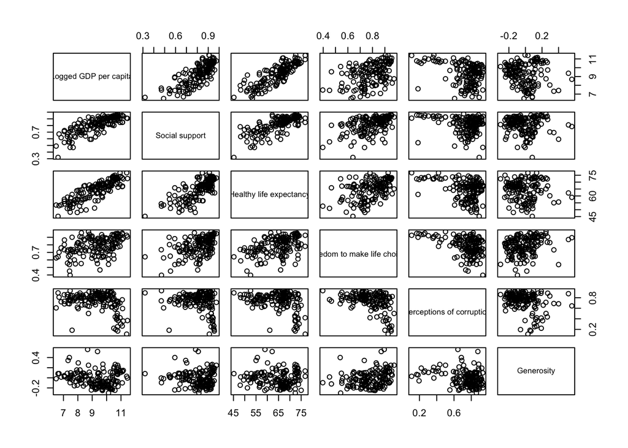

```r
whr20_few <- whr20 %>% dplyr::select(`Ladder score`, `Logged GDP per capita`,
             `Social support`,`Healthy life expectancy`,
             `Freedom to make life choices`,
             `Perceptions of corruption`,
               Generosity) %>% drop_na()
pairs(whr20_few[-1])
```

We find that GDP per capita may be highly correlated with social support, life expectancy, and freedom to make life choices. It may be a good idea to stratify by GPD per capital to further explore if and how the relationship between these variables and the Cantril Ladder score changes.

## Stratifying by GDP per Capita

```r
# Categorize by GDP, divide into 4 quadrants (gdp_cat = 0,1,2, or 3)
whr_gdp <- whr_all %>% filter(!is.na(`Log GDP per capita`))
q_gdp <- whr_gdp %>% summarise(q1 = quantile(`Log GDP per capita`)[2], q3 = quantile(`Log GDP per capita`)[4], mean = mean(`Log GDP per capita`))
quantile(whr_gdp$`Log GDP per capita`)
```

```
##        0%       25%       50%       75%      100%
##  6.456574  8.309359  9.407829 10.209482 11.728235
```

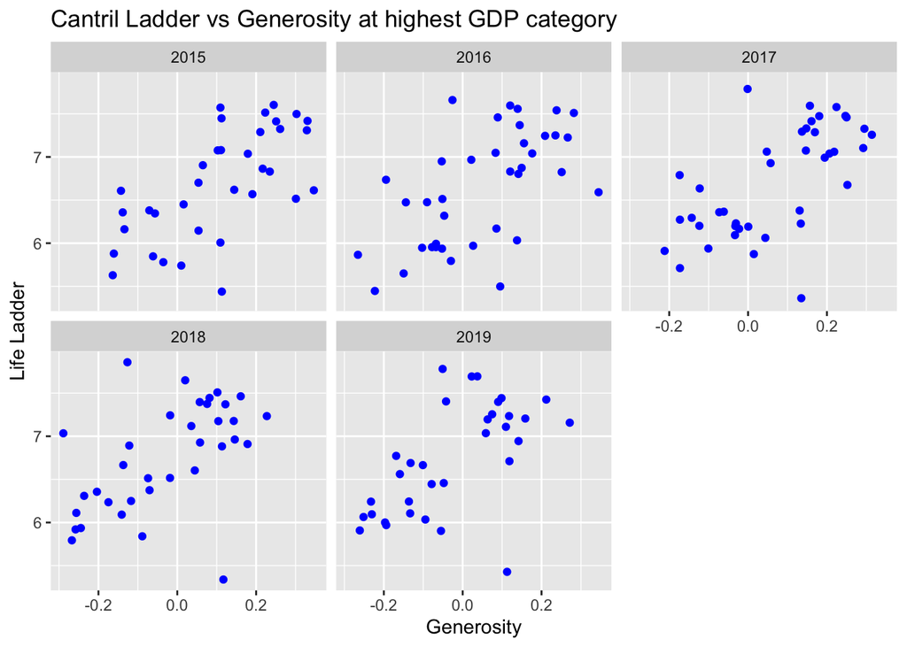

```r
whr_gdp <- whr_gdp %>% mutate(gdp_cat = cut(`Log GDP per capita`, breaks = c(-Inf, q_gdp[1], q_gdp[3], q_gdp[2], Inf), labels=c(0,1,2,3)))

# Plot gdp-stratified Cantril ladder score v.s. Generosity, since it was the least significant predictor from previous models
whr_gdp %>% filter(gdp_cat == 3, year %in% 2015:2019) %>%
  ggplot(aes(x = `Generosity`, y = `Life Ladder`)) +
  geom_point(color = "blue")+
  facet_wrap(.~year)+
  ggtitle("Cantril Ladder vs Generosity at highest GDP category")
```

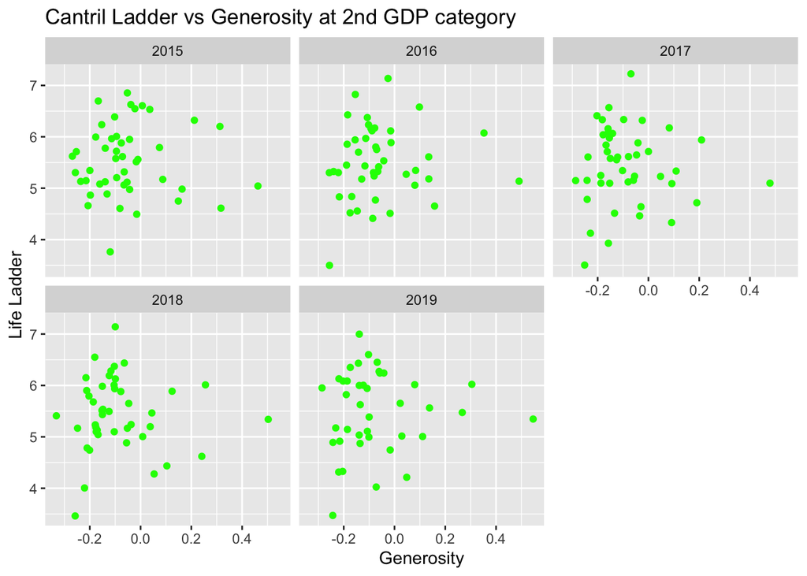

```r
whr_gdp %>% filter(gdp_cat == 2, year %in% 2015:2019) %>%
  ggplot(aes(x = `Generosity`, y = `Life Ladder`)) +
  geom_point(color = "green")+
  facet_wrap(.~year)+
  ggtitle("Cantril Ladder vs Generosity at 2nd GDP category")
```

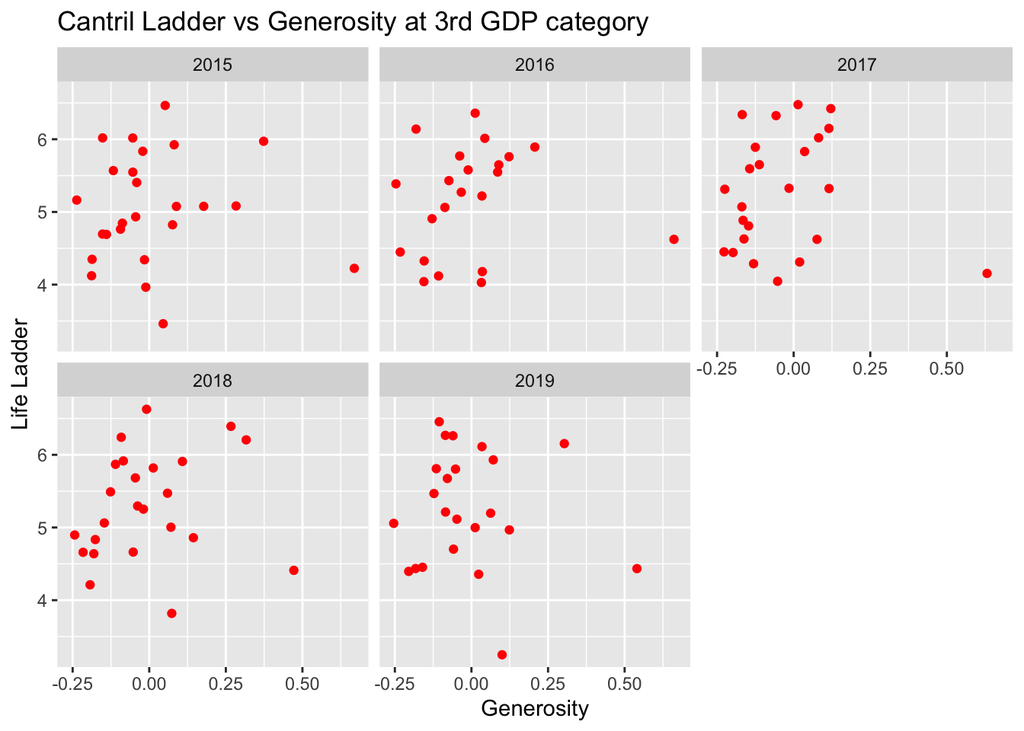

```r
whr_gdp %>% filter(gdp_cat == 1, year %in% 2015:2019) %>%
  ggplot(aes(x = `Generosity`, y = `Life Ladder`)) +
  geom_point(color = "red")+
  facet_wrap(.~year)+
  ggtitle("Cantril Ladder vs Generosity at 3rd GDP category")
```

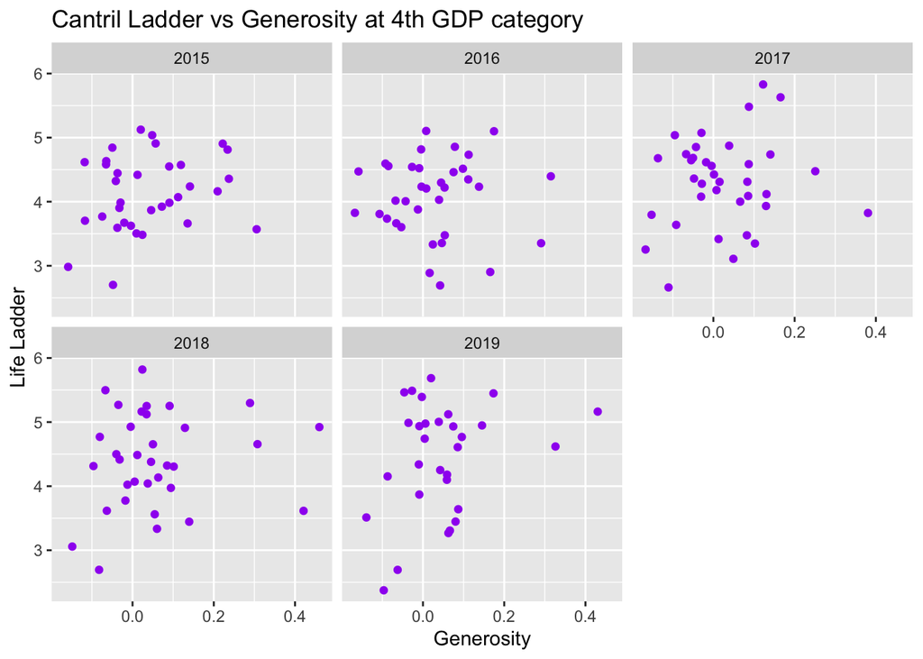

```r
whr_gdp %>% filter(gdp_cat == 0, year %in% 2015:2019) %>%
  ggplot(aes(x = `Generosity`, y = `Life Ladder`)) +
  geom_point(color = "purple")+
  facet_wrap(.~year)+
  ggtitle("Cantril Ladder vs Generosity at 4th GDP category")
```

We found that across 2015-2019, Generosity seems to be possibly correlated with Cantril Ladder score among the countries with the highest quadrant of GDP per capital.

Lets further create models from the data restricted to the highest quadrant of GDP per capita:

```r
# Create model from highest GDP per capita category stratified data
model_gdp3_year <- function(y){
  whr_df <- whr_gdp %>% filter(gdp_cat==3, year == y) %>% dplyr::select(`Life Ladder`, `Log GDP per capita`,
             `Social support`, `Healthy life expectancy at birth`,
             `Freedom to make life choices`,
             `Generosity`,
             `Perceptions of corruption`) %>% drop_na()

  mod <- lm(`Life Ladder` ~ `Log GDP per capita`+
             `Social support`+`Healthy life expectancy at birth`+
             `Freedom to make life choices`+
             `Generosity`+
             `Perceptions of corruption`,
           data = whr_df)
  mod
}

models_gdp3<- lapply(years, model_gdp3_year)
names(models_gdp3) <- paste0("models_gdp3.", 2015:2019)
lapply(models_gdp3, summary)
```

```
## $models_gdp3.2015
##
## Call:
## lm(formula = `Life Ladder` ~ `Log GDP per capita` + `Social support` +
##     `Healthy life expectancy at birth` + `Freedom to make life choices` +
##     Generosity + `Perceptions of corruption`, data = whr_df)
##
## Residuals:
##     Min      1Q  Median      3Q     Max
## -0.6781 -0.3298  0.0722  0.2491  0.7929
##
## Coefficients:
##                                     Estimate Std. Error t value Pr(>|t|)
## (Intercept)                         2.355939   5.242908   0.449   0.6574
## `Log GDP per capita`                0.121470   0.354207   0.343   0.7348
## `Social support`                    3.402606   1.894403   1.796   0.0856 .
## `Healthy life expectancy at birth` -0.008377   0.048206  -0.174   0.8636
## `Freedom to make life choices`      0.924275   1.213921   0.761   0.4542
## Generosity                          1.398605   0.588924   2.375   0.0263 *
## `Perceptions of corruption`        -0.648469   0.529450  -1.225   0.2330
## ---
## Signif. codes:  0 '***' 0.001 '**' 0.01 '*' 0.05 '.' 0.1 ' ' 1
##
## Residual standard error: 0.4055 on 23 degrees of freedom
## Multiple R-squared:  0.6963, Adjusted R-squared:  0.617
## F-statistic: 8.787 on 6 and 23 DF,  p-value: 4.907e-05
##
##
## $models_gdp3.2016
##
## Call:
## lm(formula = `Life Ladder` ~ `Log GDP per capita` + `Social support` +
##     `Healthy life expectancy at birth` + `Freedom to make life choices` +
##     Generosity + `Perceptions of corruption`, data = whr_df)
##
## Residuals:
##      Min       1Q   Median       3Q      Max
## -1.15153 -0.18373  0.07287  0.25110  0.67470
##
## Coefficients:
```

[output cut: 83 more lines]

```
## Coefficients:
##                                    Estimate Std. Error t value Pr(>|t|)
## (Intercept)                        -6.11009    3.63210  -1.682  0.10605
## `Log GDP per capita`                0.64618    0.24137   2.677  0.01346 *
## `Social support`                    4.03620    1.43231   2.818  0.00976 **
## `Healthy life expectancy at birth`  0.03875    0.02636   1.470  0.15505
## `Freedom to make life choices`      0.18059    0.96955   0.186  0.85387
## Generosity                          0.49634    0.45045   1.102  0.28191
## `Perceptions of corruption`        -1.12792    0.42860  -2.632  0.01491 *
## ---
## Signif. codes:  0 '***' 0.001 '**' 0.01 '*' 0.05 '.' 0.1 ' ' 1
##
## Residual standard error: 0.2809 on 23 degrees of freedom
## Multiple R-squared:  0.8535, Adjusted R-squared:  0.8153
## F-statistic: 22.33 on 6 and 23 DF,  p-value: 1.614e-08
```

We also want to know how would the model behave after changing GDP per capita into categorized variable. We’ll apply it to the pooled data in 2017-2019.

## Change GDP per capita into categorized variable

```r
# first create gdp category in whr20 data
whr20_gdp <- whr20 %>% filter(!is.na(`Logged GDP per capita`))
q20_gdp <- whr20_gdp %>% summarise(q1 = quantile(`Logged GDP per capita`)[2], q3 = quantile(`Logged GDP per capita`)[4], mean = mean(`Logged GDP per capita`))
whr20_gdp <- whr20_gdp %>% mutate(gdp_cat = cut(`Logged GDP per capita`, breaks = c(-Inf, q20_gdp[1], q20_gdp[3], q20_gdp[2], Inf), labels=c(0,1,2,3)))

# modeling
mod1_gdp_gen <- lm(`Ladder score` ~ gdp_cat+
             `Social support`+`Healthy life expectancy`+
             `Freedom to make life choices`+
             `Perceptions of corruption`+
               Generosity,
           data = whr20_gdp)
summary(mod1_gdp_gen)
```

```
##
## Call:
## lm(formula = `Ladder score` ~ gdp_cat + `Social support` + `Healthy life expectancy` +
##     `Freedom to make life choices` + `Perceptions of corruption` +
##     Generosity, data = whr20_gdp)
##
## Residuals:
##      Min       1Q   Median       3Q      Max
## -1.65419 -0.26785  0.06742  0.35848  1.50997
##
## Coefficients:
##                                Estimate Std. Error t value Pr(>|t|)
## (Intercept)                    -0.72445    0.79087  -0.916 0.361187
## gdp_cat1                        0.19920    0.16933   1.176 0.241372
## gdp_cat2                        0.20945    0.18935   1.106 0.270508
## gdp_cat3                        0.88287    0.24045   3.672 0.000339 ***
## `Social support`                3.02438    0.61292   4.934 2.19e-06 ***
## `Healthy life expectancy`       0.03196    0.01270   2.518 0.012910 *
## `Freedom to make life choices`  1.93391    0.49348   3.919 0.000137 ***
## `Perceptions of corruption`    -0.19501    0.33625  -0.580 0.562865
## Generosity                      0.11356    0.33164   0.342 0.732533
## ---
## Signif. codes:  0 '***' 0.001 '**' 0.01 '*' 0.05 '.' 0.1 ' ' 1
##
## Residual standard error: 0.55 on 144 degrees of freedom
## Multiple R-squared:  0.7683, Adjusted R-squared:  0.7555
## F-statistic:  59.7 on 8 and 144 DF,  p-value: < 2.2e-16
```

The result of the model showed that only the highest GDP per capita has a significant coefficient compared to the lowest GDP per capita. Category 1 and 2 showed no difference of their effect on Cantril Ladder score compared to the lowest category. The coefficients of social support, life expectancy, and freedom to make life choices remained significant as the model with continuous GDP per capita variable. Note that according to R-squared value, this model (adj-R2 = 0.7555) performs better than the original model(adj-R2 = 0.738).

# Data Analysis: Random Forest

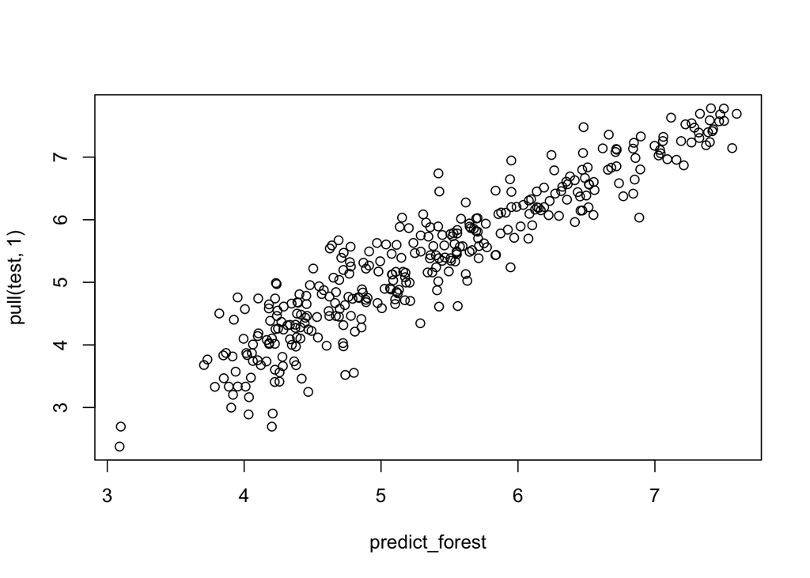

```r
machine_whr <- whr2_1 %>% dplyr::select(3:12)

machine_whr$`Confidence in national government`[is.na(machine_whr$`Confidence in national government`)] <- 0
machine_whr$PerceptionsOfCorruption[is.na(machine_whr$PerceptionsOfCorruption)] <- 0

full_machine_whr <- machine_whr %>%
  drop_na() %>%
  rename(FreedomLifeChoices = `Freedom to make life choices`,
         PositiveAffect = `Positive affect`,
         NegativeAffect = `Negative affect`,
         Confidence = `Confidence in national government`,
         LifeLadder = `Life Ladder`)

set.seed(1)

train_set <- sample(1:nrow(full_machine_whr), as.integer(nrow(full_machine_whr)*0.8))

fit_forest <- randomForest(formula = LifeLadder ~., data = full_machine_whr, subset = train_set)

predict_forest <- predict(fit_forest, newdata = full_machine_whr[-train_set, ])

test = full_machine_whr[-train_set, "LifeLadder"]

plot(predict_forest, pull(test, 1))
```

```r
mean((predict_forest - pull(test, 1))^2)
```

```
## [1] 0.1848882
```

The MSE on the test set for this random forest is 0.1848882 which seems low relative to the Life Ladder scores. This is a suggestion that the model is fairly good at predicting life ladder scores from the information we gave it (GDP, social support, life expectancy, freedom to make life choices, generosity, perceptions of corruption, positive affect, negative affect, and confidence in government). The figure plots predicted values by the model against the true values from the original dataset. The points are centered around a slope of 1 (absolute error of 0), which shows that the model is not consistently under-predicting or over-predicting life ladder scores given the other variables listed above. This model may be useful in countries that are missing survey data from the Gallup World Poll that has Cantril Ladder scores, but still want to estimate the average “happiness” levels of their population, given the appropriate variables.